[figure not shown]

# Neighborhood and Venues Data Analysis of Vancouver

- Introduction/Business Problem
- Data
- Methodology
- Analysis
- Results and Discussion
- Conclusion

## A. Introduction/Business Problem

### A.1. Description of the problem and a discussion of the background

Vancouver is a coastal seaport city in western Canada, located in the Lower Mainland region of British Columbia. As the most populous city in the province, the 2016 census recorded 631,486 people in the city, up from 603,502 in 2011. The Greater Vancouver area had a population of 2,463,431 in 2016, making it the third-largest metropolitan area in Canada. Vancouver has the highest population density in Canada, with over 5,400 people per square kilometer, which makes it the fifth-most densely populated city with over 250,000 residents in North America.Vancouver has been called a "city of neighborhoods. Each neighborhood in Vancouver has a distinct character and ethnic mix.

In this project, we will try to find an optimal location for a Cofee Shop. Specifically, this report will be targeted to investors interested in opening a Coffee Shop in Vancouver, Canada.

Since there are lots of cafes in Vancouver we will try to detect locations that are more crowded with coffee shops and well-known places for coffee lovers. Also, we will check each Borough through the number of universities and colleges due to the fact that college and university students are the potential target market for cafes.

## B. Data

### B.1. Data Description

According to the problems we need to obtain following information :

- We need a list of all $Boroughs$ and $Neighborhoods$ of Vancouver with $latitude$ and $longitude$ information.
  - To obtain this information we use web scraping technique from several sources such as Wikipedia .
- **Forsquare API** to explore the neighbors of Vancouver and segment them by type of most common running businesses .
- Coordinate of Vancouver center and neighbors will be obtained using **GeoPy**.

### B.2. Data collection

##### Getting list of neighborhoods in Vancouver

Firstly, we need to obtain a list of all official neighbors in Vancouver, which is available on Wikipedia.  
Web Scraping method is utilized here to achieve this goal.

```python
import numpy as np # library to handle data in a vectorized manner

import pandas as pd # library for data analsysis

import json # library to handle JSON files
from pandas.io.json import json_normalize # tranform JSON file into a pandas dataframe

import matplotlib.pyplot as plt
%matplotlib inline

#!conda install -c conda-forge geopy --yes # uncomment this line if you haven't completed the Foursquare API lab
!pip install geopy
from geopy.geocoders import Nominatim # convert an address into latitude and longitude values

import requests # library to handle requests
from pandas.io.json import json_normalize # tranform JSON file into a pandas dataframe

# Matplotlib and associated plotting modules
import matplotlib.cm as cm
import matplotlib.colors as colors

# import k-means from clustering stage
from sklearn.cluster import KMeans

#!conda install -c conda-forge folium=0.5.0 --yes # uncomment this line if you haven't completed the Foursquare API lab
!pip install folium
import folium # map rendering library
!pip install nbconvert
```

```
  Using cached geopy-1.21.0-py2.py3-none-any.whl (104 kB)
  Using cached geographiclib-1.50-py3-none-any.whl (38 kB)
  Using cached folium-0.10.1-py2.py3-none-any.whl (91 kB)
  Using cached branca-0.4.0-py3-none-any.whl (25 kB)
```

Extract a list of Neighborhoods :

```python
neigh_list = []
for ul in table.find_all('ul'):
    row = ""
    for li in ul.find_all('li'):
        neigh = li.text
        neigh_list.append(neigh)

neigh = neigh_list[8:30]
neigh[0] = 'Arbutus-Ridge'
neigh[20] = 'West End'
neigh
```

```
['Arbutus-Ridge',
 'Downtown',
 'Dunbar-Southlands',
 'Fairview',
 'Grandview-Woodland',
 'Hastings-Sunrise',
 'Kensington-Cedar Cottage',
 'Kerrisdale',
 'Killarney',
 'Kitsilano',
 'Marpole',
 'Mount Pleasant',
 'Oakridge',
 'Renfrew-Collingwood',
 'Riley Park',
 'Shaughnessy',
 'South Cambie',
 'Strathcona',
 'Sunset',
 'Victoria-Fraserview',
 'West End',
 'West Point Grey']
```

#### GeoPy

Here, we use GeoPy to get geographical information of all neighbors and Merge it to previous data to create a data frame of `Vancouver's Neighborhood` with **Lat** and **Long** :

```python
df_vancouver = pd.read_csv('df_vancouver.csv')
df_vancouver.drop('Unnamed: 0',1 , inplace=True)
df_vancouver
```

|  | Neighborhood | Latitude | Longitude |
| --- | --- | --- | --- |
| 0 | Arbutus-Ridge | 49.240968 | -123.167001 |
| 1 | Downtown | 49.283393 | -123.117456 |
| 2 | Dunbar-Southlands | 49.253460 | -123.185044 |
| 3 | Fairview | 49.264113 | -123.126835 |
| 4 | Grandview-Woodland | 49.270559 | -123.067942 |
| 5 | Hastings-Sunrise | 49.277594 | -123.043920 |
| 6 | Kensington-Cedar Cottage | 49.247632 | -123.084207 |
| 7 | Kerrisdale | 49.234673 | -123.155389 |
| 8 | Killarney | 49.224274 | -123.046250 |
| 9 | Kitsilano | 49.269410 | -123.155267 |
| 10 | Marpole | 49.209223 | -123.136150 |
| 11 | Mount Pleasant | 49.263330 | -123.096588 |
| 12 | Oakridge | 49.230829 | -123.131134 |
| 13 | Renfrew-Collingwood | 49.242024 | -123.057679 |
| 14 | Riley Park | 49.247438 | -123.102966 |
| 15 | Shaughnessy | 49.251863 | -123.138023 |
| 16 | South Cambie | 49.246685 | -123.120915 |
| 17 | Strathcona | 49.279554 | -123.089979 |
| 18 | Sunset | 49.219593 | -123.090239 |
| 19 | Victoria-Fraserview | 49.218416 | -123.073287 |
| 20 | West End | 49.284131 | -123.131795 |
| 21 | West Point Grey | 49.264484 | -123.185433 |

##### Visualizing Neighborhoods of Vancouver using $Folium$ :

```python
geolocator = Nominatim(user_agent="ca_explorer")
va_loc = geolocator.geocode('Vancouver, Canada')
# create map of New York using latitude and longitude values
map_vancouver = folium.Map(location=[va_loc.latitude, va_loc.longitude], zoom_start=12)

# add markers to map
for lat, lng, neighborhood in zip(df_vancouver['Latitude'], df_vancouver['Longitude'], df_vancouver['Neighborhood']):
    label = '{}'.format(neighborhood)
    label = folium.Popup(label, parse_html=True)
    folium.CircleMarker(
        [lat, lng],
        radius=5,
        popup=label,
        color='blue',
        fill=True,
        fill_color='#3186cc',
        fill_opacity=0.7,
        parse_html=False).add_to(map_vancouver)

map_vancouver
```

[interactive chart not shown]

### Foursquare

Now that we have our location, let's use $Foursquare API$ to get info on coffee shops in each neighborhood with the limit as **100 venue** and the **radius 1000 meter** .

We're interested in venues in Coffee Shop, Cafeteria, Cafe, Residental categories, Universities, Public Transportation, etc.

We are trying to get all relative and effective information of neighbors to attain a perception of the characteristic of each neighbor. Therefore it is not quite sufficient to include only coffee shops to our calculations.

*Coffee Shop 4bf58dd8d48988d1e0931735 Cafeteria 4bf58dd8d48988d128941735 Cafe 4bf58dd8d48988d16d941735 Corporate Coffee Shop 5665c7b9498e7d8a4f2c0f06 Residence 4e67e38e036454776db1fb3a Bus Station 4bf58dd8d48988d1fe931735 Bus Stop 52f2ab2ebcbc57f1066b8b4f Hotel 4bf58dd8d48988d1fa931735 Metro Station 4bf58dd8d48988d1fd931735 College & University 4d4b7105d754a06372d81259 Office 4bf58dd8d48988d124941735 Bank 4bf58dd8d48988d10a951735*

```python
#df_neighbors_t = getNearbyVenues(df_vancouver['Neighborhood'],CATEGORIES , df_vancouver['Latitude'], df_vancouver['Longitude'] )
df_neighbors_t= pd.read_csv('df_neighbors_t.csv')
#df_off_bank = getNearbyVenues(df_vancouver['Neighborhood'],CATEGORIES , df_vancouver['Latitude'], df_vancouver['Longitude'] )
df_neighbors_t.drop( 'Unnamed: 0' , 1 , inplace=True)
#with open('df_neighbors_t.csv' , 'w'):
#     df_neighbors_t.to_csv('df_neighbors_t.csv')

df_neighbors_t.head()
```

|  | Neighborhood | Neighborhood Latitude | Neighborhood Longitude | Name | Venue Name | Venue Latitude | Venue Longitude | Venue Category |
| --- | --- | --- | --- | --- | --- | --- | --- | --- |
| 0 | Arbutus-Ridge | 49.240968 | -123.167001 | Amy Tsao - Remax Select | 5487 West Boulevard | 49.236660 | -123.155724 | Building |
| 1 | Arbutus-Ridge | 49.240968 | -123.167001 | Revera Crofton Manor | 2803 West 41st Ave (MacDonald St) | 49.235349 | -123.167768 | Assisted Living |
| 2 | Downtown | 49.283393 | -123.117456 | Rosewood Hotel Georgia | 801 W Georgia St (at Howe St) | 49.283429 | -123.118911 | Hotel |
| 3 | Downtown | 49.283393 | -123.117456 | Fairmont Pacific Rim | 1038 Canada Pl. (btwn Burrard & Thurlow) | 49.288227 | -123.116932 | Hotel |
| 4 | Downtown | 49.283393 | -123.117456 | Sutton Place Hotel | 845 Burrard St (btwn Smithe St & Robson St) | 49.282640 | -123.123875 | Hotel |

What are the unique categories in our data set ?

```python
df_neighbors_t['Venue Category'].unique()
```

```
array(['Building', 'Assisted Living', 'Hotel',
       'Residential Building (Apartment / Condo)', 'Office',
       'Housing Development', 'Bus Station', 'Bus Line', 'Bus Stop',
       'Train Station', 'Light Rail Station', 'Lounge', 'Hotel Bar',
       'French Restaurant', 'Spa', 'Café', 'Hostel', 'Bar', 'Motel',
       'American Restaurant', 'Tourist Information Center',
       'Bed & Breakfast', 'Inn', 'Vacation Rental', 'Metro Station',
       'Grocery Store', 'Liquor Store', 'Farmers Market', 'Restaurant',
       'Breakfast Spot', 'Food & Drink Shop', 'Supermarket',
       'Italian Restaurant', 'Miscellaneous Shop', 'Pharmacy',
       'Trade School', 'Health Food Store', 'Wine Shop', 'Cocktail Bar',
       'Diner', 'Coffee Shop', 'Pub', 'Deli / Bodega', 'Gourmet Shop',
       'Supplement Shop', 'Food Service', 'Japanese Restaurant',
       'Indian Restaurant', 'Street Food Gathering', 'Sushi Restaurant',
       'Sandwich Place', 'Butcher', 'Beer Store', 'Cheese Shop',
       'Seafood Restaurant', 'Fish Market', 'Brewery',
       'Convenience Store', 'Organic Grocery', 'Fast Food Restaurant',
       'Tea Room', 'Park', 'Bakery', 'Greek Restaurant', 'Cafeteria',
       'College Cafeteria', 'Dessert Shop', 'Chinese Restaurant',
       'Ice Cream Shop', 'Asian Restaurant', 'Snack Place', 'University',
       'General College & University', 'College Academic Building',
       'Student Center', 'Language School', 'College & University',
       'College Classroom', 'Community College', 'School',
       'College Administrative Building', 'College Library',
       'College Science Building', 'Medical School', 'College Lab',
       'College Technology Building', 'Hospital', 'High School',
       'College Theater', 'College Arts Building', 'Salon / Barbershop',
       'Art Gallery', 'College Rec Center', 'College Gym',
       'Government Building', 'Advertising Agency',
       'Paper / Office Supplies Store', 'General Entertainment',
       'Coworking Space', 'Non-Profit', 'Tech Startup',
       'Electronics Store', 'Business Service', 'Medical Center',
       "Dentist's Office", 'Bank', 'IT Services', 'Real Estate Office',
       'Film Studio', 'Campaign Office', 'Auto Dealership'], dtype=object)
```

We need to clean our data set and remove some unnecessary data and columns

##### Group by Neighborhoods and selected categories

Here we slice data frame to selected efficient categories and then group them by Neighborhood to find out density in each neighborhood.

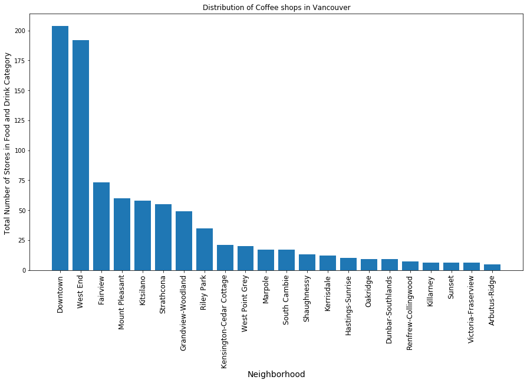

```python
#bar chart
plt.subplots(figsize=(15,8))
plt.bar(df_count_stores_group['Neighborhood'], df_count_stores_group['Name'], data=df_count_stores_group )
plt.xticks(rotation=90 ,fontsize = 12)
plt.xlabel('Neighborhood',fontsize = 14) # add to x-label to the plot
plt.ylabel('Total Number of Stores in Food and Drink Category ',fontsize = 12) # add y-label to the plot
plt.title('Distribution of Coffee shops in Vancouver') # add title to the plot

plt.show()
```

#### Finding top 5 most dense neighbors by Coffee shops, Cafes and related Stores

```python
df_count_stores_group.head()
```

|  | Neighborhood | Name |
| --- | --- | --- |
| 0 | Downtown | 204 |
| 1 | West End | 192 |
| 2 | Fairview | 73 |
| 3 | Mount Pleasant | 60 |
| 4 | Kitsilano | 58 |

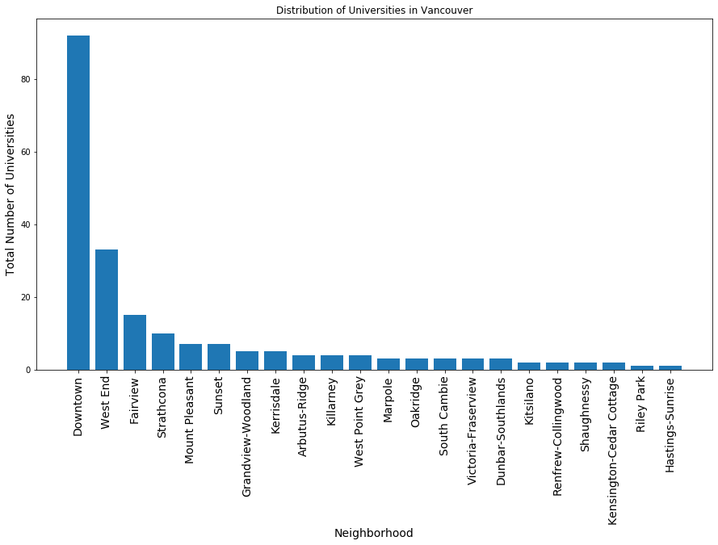

```python
uni = ('College Cafeteria','University',
       'General College & University', 'College Academic Building',
       'Student Center', 'Language School', 'College & University',
       'College Classroom', 'Community College', 'School',
       'College Administrative Building', 'College Library',
       'College Science Building', 'Medical School', 'College Lab',
       'College Technology Building', 'Hospital', 'High School',
       'College Theater', 'College Arts Building', 'Salon / Barbershop',
       'Art Gallery','College Rec Center', 'College Gym',)

df_count_uni= df_req[df_req['Venue Category'].isin(uni)]
df_count_uni_group = df_count_uni.groupby('Neighborhood').count().sort_values("Name", ascending = False).reset_index()[['Neighborhood' ,'Name' ]]


#bar chart
plt.subplots(figsize=(15,8))
plt.bar(df_count_uni_group['Neighborhood'], df_count_uni_group['Name'], data=df_count_uni_group )
plt.xticks(rotation=90 ,fontsize = 14)
plt.xlabel('Neighborhood',fontsize = 14) # add to x-label to the plot
plt.ylabel('Total Number of Universities',fontsize = 14) # add y-label to the plot
plt.title('Distribution of Universities in Vancouver') # add title to the plot

plt.show()
```

#### Finding top 5 most surrounded neighbors by Universities and Colleges

```python
df_count_uni_group.head(5)
```

|  | Neighborhood | Name |
| --- | --- | --- |
| 0 | Downtown | 92 |
| 1 | West End | 33 |
| 2 | Fairview | 15 |
| 3 | Strathcona | 10 |
| 4 | Mount Pleasant | 7 |

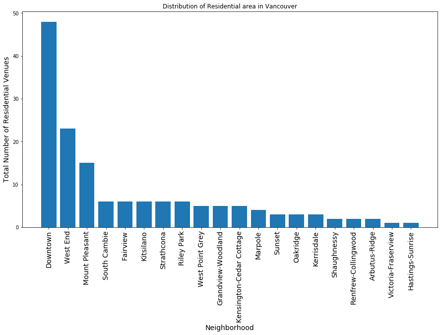

```python
res = ('Building', 'Assisted Living',
       'Residential Building (Apartment / Condo)',
       'Housing Development'

         )
df_count_res= df_req[df_req['Venue Category'].isin(res)]
df_count_res_group = df_count_res.groupby('Neighborhood').count().sort_values("Name", ascending = False).reset_index()[['Neighborhood' ,'Name' ]]
#bar chart
plt.subplots(figsize=(15,8))
plt.bar(df_count_res_group['Neighborhood'], df_count_res_group['Name'], data=df_count_res_group )
plt.xticks(rotation=90 ,fontsize = 14)
plt.xlabel('Neighborhood',fontsize = 14) # add to x-label to the plot
plt.ylabel('Total Number of Residential Venues',fontsize = 14) # add y-label to the plot
plt.title('Distribution of Residential area in Vancouver') # add title to the plot

plt.show()
```

#### Finding top 5 Residential Neighbors

```python
df_count_res_group.head()
```

|  | Neighborhood | Name |
| --- | --- | --- |
| 0 | Downtown | 48 |
| 1 | West End | 23 |
| 2 | Mount Pleasant | 15 |
| 3 | South Cambie | 6 |
| 4 | Fairview | 6 |

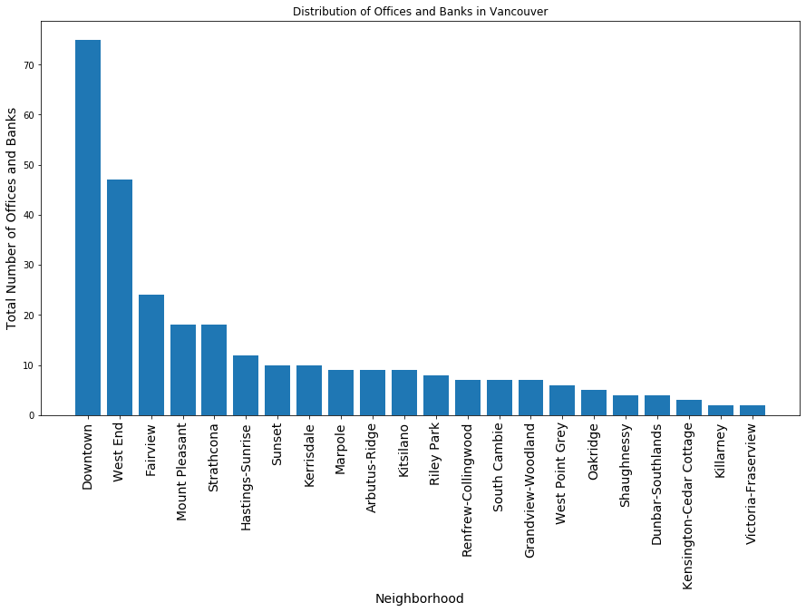

```python
bank = ('Government Building', 'Advertising Agency',
       'Paper / Office Supplies Store', 'General Entertainment',
       'Coworking Space', 'Non-Profit', 'Tech Startup',
       'Electronics Store', 'Business Service', 'Medical Center',
             'Bank'
         )
df_count_bank= df_req[df_req['Venue Category'].isin(bank)]
df_count_bank_group = df_count_bank.groupby('Neighborhood').count().sort_values("Name", ascending = False).reset_index()[['Neighborhood' ,'Name' ]]
#bar chart
plt.subplots(figsize=(15,8))
plt.bar(df_count_bank_group['Neighborhood'], df_count_bank_group['Name'], data=df_count_bank_group )
plt.xticks(rotation=90 ,fontsize = 14)
plt.xlabel('Neighborhood',fontsize = 14) # add to x-label to the plot
plt.ylabel('Total Number of Offices and Banks',fontsize = 14) # add y-label to the plot
plt.title('Distribution of Offices and Banks in Vancouver') # add title to the plot

plt.show()
```

#### Finding top 5 surrounded neighbors by Offices and Banks

```python
df_count_bank_group.head(5)
```

|  | Neighborhood | Name |
| --- | --- | --- |
| 0 | Downtown | 75 |
| 1 | West End | 47 |
| 2 | Fairview | 24 |
| 3 | Mount Pleasant | 18 |
| 4 | Strathcona | 18 |

## C. Methodology

In this project, we are trying to detect the neighborhoods with a **high density** of Coffee shops and related stores. Furthermore, we are interested in areas which have the **most colleges and universities**.

Within the first step, all the **required data** has been collected such as the list of all neighbors in Vancouver with geographic information.

Then, we utilized the **Foursquare API** to locate each neighbors coffee shops and related trades. Next, according to returned data from Foursquare API, we did some `analysis` to figure out the `Density of Coffee shops and Colleges across all neighbors`.

In the final step of our analysis, we will use `unsupervised` learning **K-means algorithm** to cluster the boroughs. K-Means algorithm is one of the most common cluster methods of unsupervised learning.

### Analysis

#### One Hot Encoding

Changing the shape of our data frame to have our data in numeric form and get it ready for the clustering method.

```python
vancouver_grouped = vancouver_onehot.groupby('Neighborhood').sum().reset_index()
vancouver_grouped.head()
```

|  | Neighborhood | Advertising Agency | Art Gallery | Assisted Living | Bank | Bar | Bed & Breakfast | Building | Bus Line | Bus Station | ... | Non-Profit | Office | Paper / Office Supplies Store | Residential Building (Apartment / Condo) | Salon / Barbershop | School | Student Center | Tech Startup | Train Station | University |
| --- | --- | --- | --- | --- | --- | --- | --- | --- | --- | --- | --- | --- | --- | --- | --- | --- | --- | --- | --- | --- | --- |
| 0 | Arbutus-Ridge | 1 | 0 | 1 | 7 | 0 | 0 | 1 | 2 | 3 | ... | 0 | 3 | 0 | 0 | 0 | 0 | 1 | 0 | 0 | 1 |
| 1 | Downtown | 0 | 0 | 0 | 50 | 1 | 0 | 2 | 22 | 18 | ... | 1 | 74 | 1 | 46 | 0 | 1 | 18 | 11 | 0 | 8 |
| 2 | Dunbar-Southlands | 0 | 0 | 0 | 4 | 0 | 0 | 0 | 0 | 4 | ... | 0 | 4 | 0 | 0 | 0 | 1 | 0 | 0 | 0 | 0 |
| 3 | Fairview | 2 | 0 | 0 | 18 | 0 | 0 | 0 | 5 | 10 | ... | 0 | 23 | 0 | 6 | 0 | 1 | 1 | 1 | 0 | 1 |
| 4 | Grandview-Woodland | 0 | 0 | 1 | 7 | 0 | 1 | 0 | 3 | 2 | ... | 0 | 5 | 0 | 4 | 0 | 0 | 0 | 0 | 0 | 0 |

5 rows × 57 columns

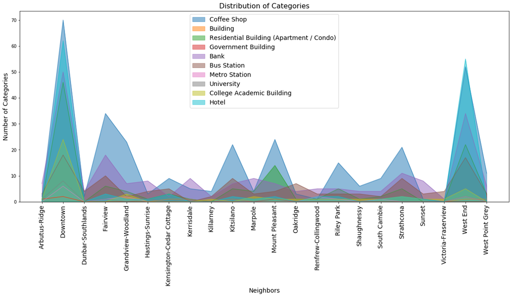

```python
ax = vancouver_grouped[['Neighborhood','Coffee Shop','Building',
                        'Residential Building (Apartment / Condo)',
                        'Government Building', 'Bank',
                        'Bus Station','Metro Station','University',
                         'College Academic Building',
                        'Hotel'

                       ]].plot(
                            #x=vancouver_grouped['Neighborhood'].values,
                            kind='area',
                            figsize=(20,8),
                            #width = 0.8,
                            #alpha=.25, # 0-1, default value a= 0.5
                            stacked=False,
                            #colormap='tab20',
                            #color = colors1
                            xticks=vancouver_grouped.index,
                            #   color=['#5cb85c' , '#5bc0de', '#d9534f' ],
                           )


plt.title('Distribution of Categories' , fontsize=16 )
plt.xlabel('Neighbors' ,fontsize = 14)
plt.ylabel('Number of Categories',fontsize = 14)
plt.legend( prop={'size': 14} )
plt.xticks( visible=True ,rotation=90 , fontsize = 14)
ax.set_xticklabels(vancouver_grouped.Neighborhood)

plt.show()
```

##### Now let's create the new dataframe and display the top venues for each neighborhood.

First, let's write a function to sort the venues in descending order.

```python
num_top_venues = 10

indicators = ['st', 'nd', 'rd']

# create columns according to number of top venues
columns = ['Neighborhood']
for ind in np.arange(num_top_venues):
    try:
        columns.append('{}{} Most Common Venue'.format(ind+1, indicators[ind]))
    except:
        columns.append('{}th Most Common Venue'.format(ind+1))

# create a new dataframe
neighborhoods_venues_sorted = pd.DataFrame(columns=columns)
neighborhoods_venues_sorted['Neighborhood'] = vancouver_grouped['Neighborhood']

for ind in np.arange(vancouver_grouped.shape[0]):
    neighborhoods_venues_sorted.iloc[ind, 1:] = return_most_common_venues(vancouver_grouped.iloc[ind, :], num_top_venues)

neighborhoods_venues_sorted.head()
```

|  | Neighborhood | 1st Most Common Venue | 2nd Most Common Venue | 3rd Most Common Venue | 4th Most Common Venue | 5th Most Common Venue | 6th Most Common Venue | 7th Most Common Venue | 8th Most Common Venue | 9th Most Common Venue | 10th Most Common Venue |
| --- | --- | --- | --- | --- | --- | --- | --- | --- | --- | --- | --- |
| 0 | Arbutus-Ridge | Bank | Bus Stop | Bus Station | Office | Bus Line | Café | Coffee Shop | University | Government Building | Assisted Living |
| 1 | Downtown | Café | Office | Coffee Shop | Hotel | Bank | Residential Building (Apartment / Condo) | Bus Stop | College Academic Building | Bus Line | General College & University |
| 2 | Dunbar-Southlands | Café | Bus Stop | Office | Bank | Bus Station | Coffee Shop | Community College | College Classroom | Cafeteria | School |
| 3 | Fairview | Café | Coffee Shop | Bus Stop | Office | Bank | Bus Station | Residential Building (Apartment / Condo) | Bus Line | Cafeteria | Hotel |
| 4 | Grandview-Woodland | Coffee Shop | Café | Bank | Bus Stop | Office | Residential Building (Apartment / Condo) | College Academic Building | Cafeteria | Bus Line | Metro Station |

## Cluster Neighborhoods

First we run **Elbow Method** for finding the optimal value of k in KMeans.

Then, we run k-means by optimal K value.

`The Elbow Method is one of the most popular methods to determine this optimal value of k`.

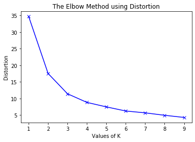

```python
#refine our data to fit the model
vancouver_grouped_clustering = vancouver_grouped.drop('Neighborhood', 1)


distortions = []
inertias = []
mapping1 = {}
mapping2 = {}
K = range(1,10)

for k in K:
    #Building and fitting the model
    kmeanModel = KMeans(n_clusters=k).fit(vancouver_grouped_clustering)
    #kmeanModel.fit(vancouver_grouped_clustering)

    distortions.append(sum(np.min(cdist(vancouver_grouped_clustering, kmeanModel.cluster_centers_,
                      'euclidean'),axis=1)) / vancouver_grouped_clustering.shape[0])
    inertias.append(kmeanModel.inertia_)

    mapping1[k] = sum(np.min(cdist(vancouver_grouped_clustering, kmeanModel.cluster_centers_,
                 'euclidean'),axis=1)) / vancouver_grouped_clustering.shape[0]
    mapping2[k] = kmeanModel.inertia_

plt.plot(K, distortions, 'bx-')
plt.xlabel('Values of K')
plt.ylabel('Distortion')
plt.title('The Elbow Method using Distortion')
plt.show()
```

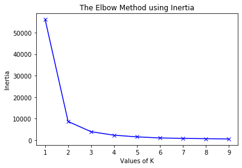

```python
plt.plot(K, inertias, 'bx-')
plt.xlabel('Values of K')
plt.ylabel('Inertia')
plt.title('The Elbow Method using Inertia')
plt.show()
```

#### Now, we have the optimal value of K which is : **K=3**

it means, in the best condition our data should be clustered to `3 groups`.

```python
# add clustering labels
neighborhoods_venues_sorted.insert(0, 'Cluster Labels', kmeans.labels_)

vancouver_merged = df_vancouver

# merge vancouver_grouped with vancouver data (df_vancouver) to add latitude/longitude for each neighborhood
vancouver_merged = vancouver_merged.join(neighborhoods_venues_sorted.set_index('Neighborhood'), on='Neighborhood')

vancouver_merged.head() # check the last columns!
```

|  | Neighborhood | Latitude | Longitude | Cluster Labels | 1st Most Common Venue | 2nd Most Common Venue | 3rd Most Common Venue | 4th Most Common Venue | 5th Most Common Venue | 6th Most Common Venue | 7th Most Common Venue | 8th Most Common Venue | 9th Most Common Venue | 10th Most Common Venue |
| --- | --- | --- | --- | --- | --- | --- | --- | --- | --- | --- | --- | --- | --- | --- |
| 0 | Arbutus-Ridge | 49.240968 | -123.167001 | 2 | Bank | Bus Stop | Bus Station | Office | Bus Line | Café | Coffee Shop | University | Government Building | Assisted Living |
| 1 | Downtown | 49.283393 | -123.117456 | 1 | Café | Office | Coffee Shop | Hotel | Bank | Residential Building (Apartment / Condo) | Bus Stop | College Academic Building | Bus Line | General College & University |
| 2 | Dunbar-Southlands | 49.253460 | -123.185044 | 2 | Café | Bus Stop | Office | Bank | Bus Station | Coffee Shop | Community College | College Classroom | Cafeteria | School |
| 3 | Fairview | 49.264113 | -123.126835 | 0 | Café | Coffee Shop | Bus Stop | Office | Bank | Bus Station | Residential Building (Apartment / Condo) | Bus Line | Cafeteria | Hotel |
| 4 | Grandview-Woodland | 49.270559 | -123.067942 | 0 | Coffee Shop | Café | Bank | Bus Stop | Office | Residential Building (Apartment / Condo) | College Academic Building | Cafeteria | Bus Line | Metro Station |

## D. Result and Discussion

Finally, the study has come to an end by visualizing clustered neighbors on the **Folium map**.

```python
# create map
map_clusters = folium.Map(location=[va_loc.latitude, va_loc.longitude], zoom_start=12)

# set color scheme for the clusters
x = np.arange(kclusters)
ys = [i + x + (i*x)**2 for i in range(kclusters)]
colors_array = cm.rainbow(np.linspace(0, 1, len(ys)))
rainbow = [colors.rgb2hex(i) for i in colors_array]

# add markers to the map
markers_colors = []
for lat, lon, poi, cluster in zip(vancouver_merged['Latitude'], vancouver_merged['Longitude'], vancouver_merged['Neighborhood'], vancouver_merged['Cluster Labels']):
    label = folium.Popup(str(poi) + ' Cluster :' + str(cluster), parse_html=True)
    folium.CircleMarker(
        [lat, lon],
        radius=5,
        popup=label,
        color=rainbow[cluster-1],
        fill=True,
        fill_color=rainbow[cluster-1],
        fill_opacity=0.7).add_to(map_clusters)

map_clusters
```

[interactive chart not shown]

#### Analyzing each Cluster

We can also estimate the number of most common venues in each cluster. Thus, we can create a bar chart which may help us to find proper labels for each cluster.

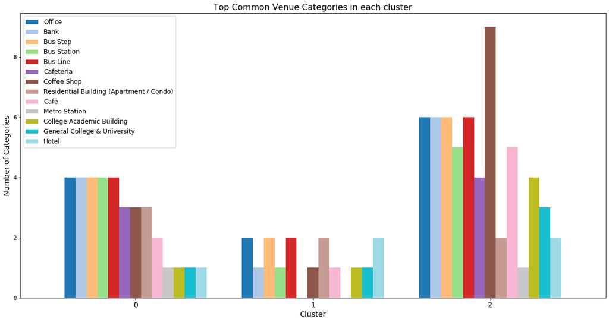

```python
ax = cluster_freq.plot(kind ='bar',
                       figsize=(20,10),
                        width = 0.8,
                       colormap='tab20',
                       #color = colors1

                      # color=['#5cb85c' , '#5bc0de', '#d9534f' ],
                           )


plt.title('Top Common Venue Categories in each cluster' , fontsize=16 )
plt.xlabel('Cluster' ,fontsize = 14)
plt.ylabel('Number of Categories',fontsize = 14)
plt.legend( prop={'size':12} )
plt.xticks(rotation=0 , fontsize = 14)


plt.show()
```

# **We take the 10 most common venue into our consideration**

## F. Conclusion

The objective of this project was to analyze Vancouver neighbors trough the number of Coffee Shops, Universities, residential areas, offices, hotel and banks in order to assist investors who want to choose an optimal location for their trade.  
By measuring coffee shop and university density distribution from Foursquare API we have first identified neighbors with the highest density,  
then we grouped neighbors by machine learning method and revealed some of the most important characteristics of each cluster.

The final decision on optimal coffee shop location will be made by stakeholders based on specific characteristics of neighborhoods and provided data in this study.  
Also, other interested people can achieve better outcomes and understandings by this kind of information.